# Feature Selection and Dimensionality Reduction

26.07.2021

## Single Cell RNAseq Analysis Workflow

[figure not shown]

## Dimensionality reduction

- Cells are characterized by the expression values of all genes –> thousands of dimensions
- Simplify complexity, so it becomes easier to work with (reduce the number of features/genes).
  - Making clustering step easier
  - Making visualization easier
- Remove redundancies in the data
  - Expression of many genes are correlated, we don’t need so many dimensions to distinguish cell types
  - Identify the most relevant information and overcome the extensive technical noise in scRNA-seq data
- Reduce computational time for downstream procedures

## There are many dimensionality reduction algorithms

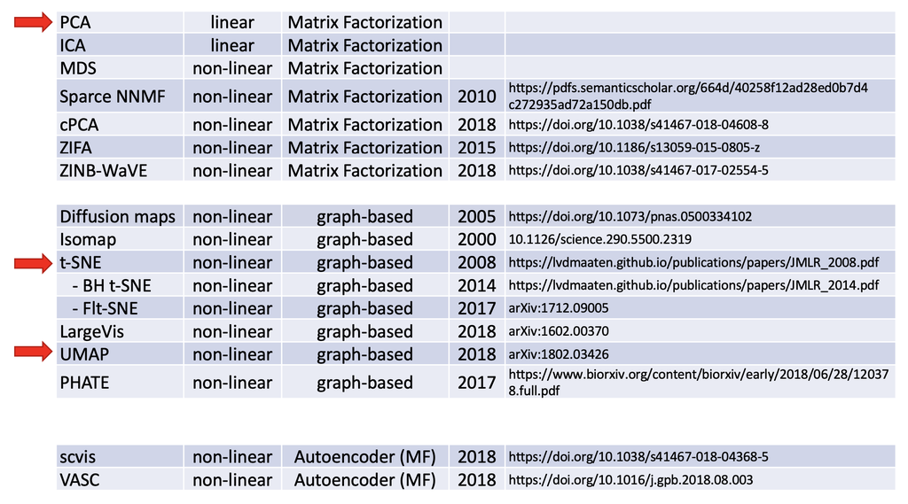

## Principal Component Anaalysis (PCA)

- It’s a linear algebraic method of dimensionality reduction
- Finds principal components (PCs) of the data
  - Directions where the data is most spread out = where there is most variance
  - PC1 explains most of the variance in the data, then PC2, PC3, ..
- We will select the most important PCs and use them for clustering cells
  - Instead of 20,000 genes we have now maybe 10 PCs
  - Essentially, each PC represents a robust ‘metagene’ that combines information across a correlated gene set
- Prior to PCA we scale the data so that genes have equal weight in downstream analysis and highly expressed genes don’t dominate

## Visualizing PCA results: loadings

[figure not shown]

Visualize top genes associated with principal components

Which genes are important for PC1 ?

## Visualizing PCA results: heatmaps

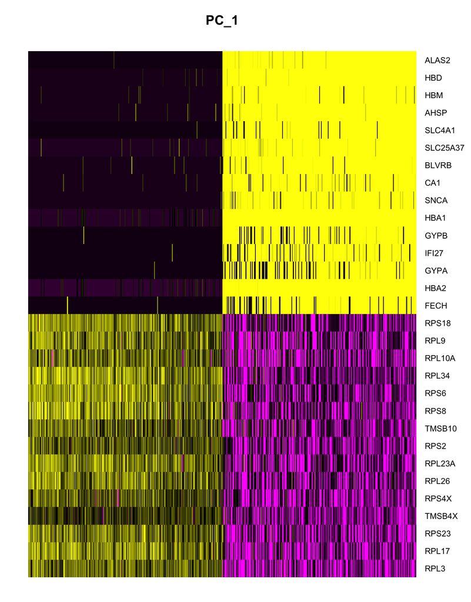

Which genes correspond to seperating cells?

Both cells and genes are ordered according to their PCA scores. Plots the extreme cells on both ends of the spectrum.

## Visualizing PCA results: PCA plot

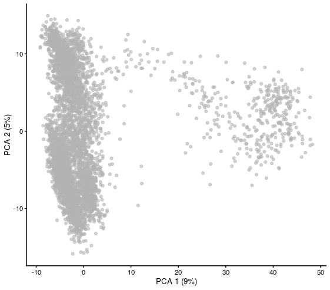

Gene expression patterns will be captured by PCs -> PCA can seperate cell types

Note that PCA can also capture other things, like sequencing depth or cell heterogeneity/complexity!

## Determine the significant principal components

- It is important to select the significant PCs for clustering analysis
- However, estimating the true dimensionality of a dataset is challenging
- Common practices include:
  - Using Elbow plot
  - Using technical noise
  - Trying downstream analysis with different number of PCs (10, 20, or even 50)

## Other dimension reduction methods: used for visualization

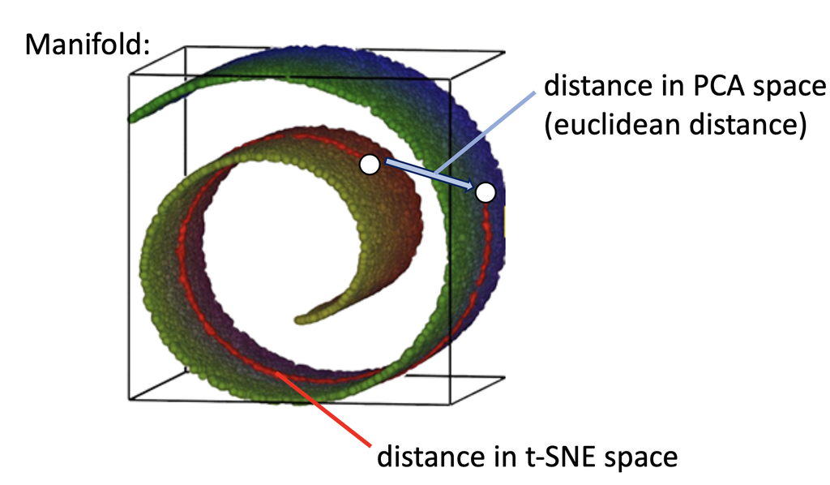

Graph-based, non-linear methods like tSNE and UMAP

PCA, tSNE and UMAP available as options in most tools

We use PCA for dimension reduction before clustering, and tSNE and UMAP for visualization

## tSNE

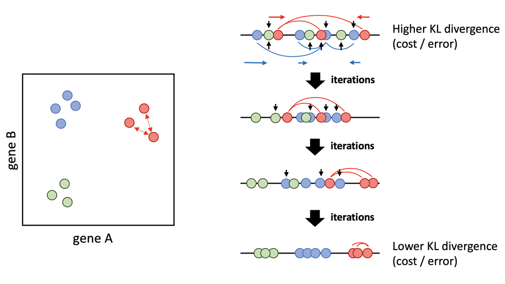

Graph-based

Non-linear

Stochastic

(Only) local distances are preserved: distance between groups are not meaningful

Can be run on top of PCs

Many parameters to optimize

## UMAP

- Non-linear graph-based dimension reduction method like tSNE
- Newer & efficient = fast
- Runs on top of PCs
- Based on topological structures in multidimensional space
- Unlike tSNE, you can compute the structure once (no randomization)
  - faster
  - you could add data points without starting over
- Presever the global structure better than tSNE

## Commands

- Find variable genes: `getTopHVGs`
- Calculate PCA: `runPCA`
- Find optimum number of PCs
- Calculate tSNE and UMAP: `runTSNE`, `runUMAP`

## Acknowledgments

Slides are adapted from Paulo Czarnewski